# Tarea-08

Roman Alberto Velez Jimenez

Iniciamos la tarea estableciendo una semilla para el generador de números aleatorios.

```r
set.seed(38972938)
```

### Cobertura

Supón que estamos interesados en entender como es el tráfico de llamadas a un conmutador, antes de realizar el estudio hacemos un análisis de simulación para estudiar el comportamiento de nuestro estimador bajo el supuesto que las llamadas al conmutador siguen un proceso $Poisson(\lambda)$.

En este ejemplo la cantidad de interés es $P(X=0)^2 = e^{-2\lambda}$ que corresponde a la probabilidad de que no se reciban llamadas en 2 minutos.

Entonces el parámetro de interés $\theta=e^{-2\lambda}$ que estimaremos con el estimador plug-in $\hat{\theta}=e^{-2\bar{X}}$.

Sigue el siguiente proceso:

1. Genera una muestra aleatoria de tamaño n = 50 de una distribución Poisson con parámetro $\lambda = 3$ (revisa la función rpois).

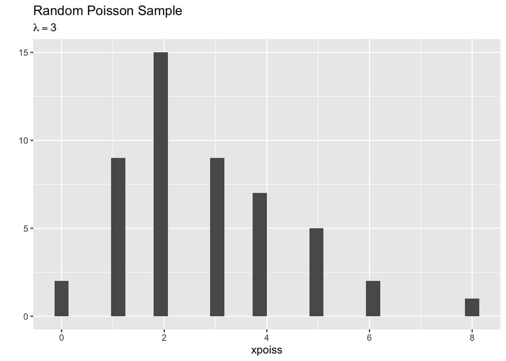

```r
# generate
xpoiss <- rpois(n = 50, lambda = 3)

# plot
qplot(xpoiss, geom = "histogram") +
  ggtitle("Random Poisson Sample", TeX("$\\lambda = 3$"))
```

2. Genera 1000 muestras bootstrap y calcula intervalos de confianza del 95% para $\hat{\theta}$ usando 1) el método normal y 2) percentiles.

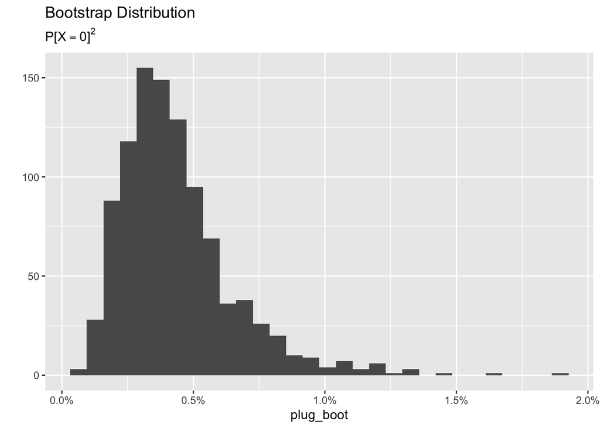

```r
# plug-in
plugin_poiss <- function(x) return(exp(-2 * mean(x)))

# bootstrap
B <- 1000
plug_boot <- sapply(1:B, function(i) plugin_poiss(sample(xpoiss, size = length(xpoiss), replace = TRUE)))

# plot
qplot(plug_boot, geom = "histogram") +
  ggtitle("Bootstrap Distribution", TeX("$ P[X = 0]^{2}$")) +
  scale_x_continuous(labels = scales::percent)
```

```r
# CI
std_boot <- sd(plug_boot)
alpha <- 0.05
cinorm <- c(mean(plug_boot) + qnorm(alpha/2)*std_boot, mean(plug_boot) + qnorm(1-alpha/2)*std_boot)
ciperc <- quantile(plug_boot, p = c(alpha/2, 1-alpha/2))

knitr::kable(
  tibble(
    norm = cinorm,
    perc = ciperc,
    type = c("lower", "upper")
  )
)
```

| norm | perc | type |
| --- | --- | --- |
| 0.0001077 | 0.0015338 | lower |
| 0.0086048 | 0.0100518 | upper |

3. Revisa si el intervalo de confianza contiene el verdadero valor del parámetro, en caso de que no lo contenga registra si falló por la izquierda o falló por la derecha, así como la longitud del intervalo.

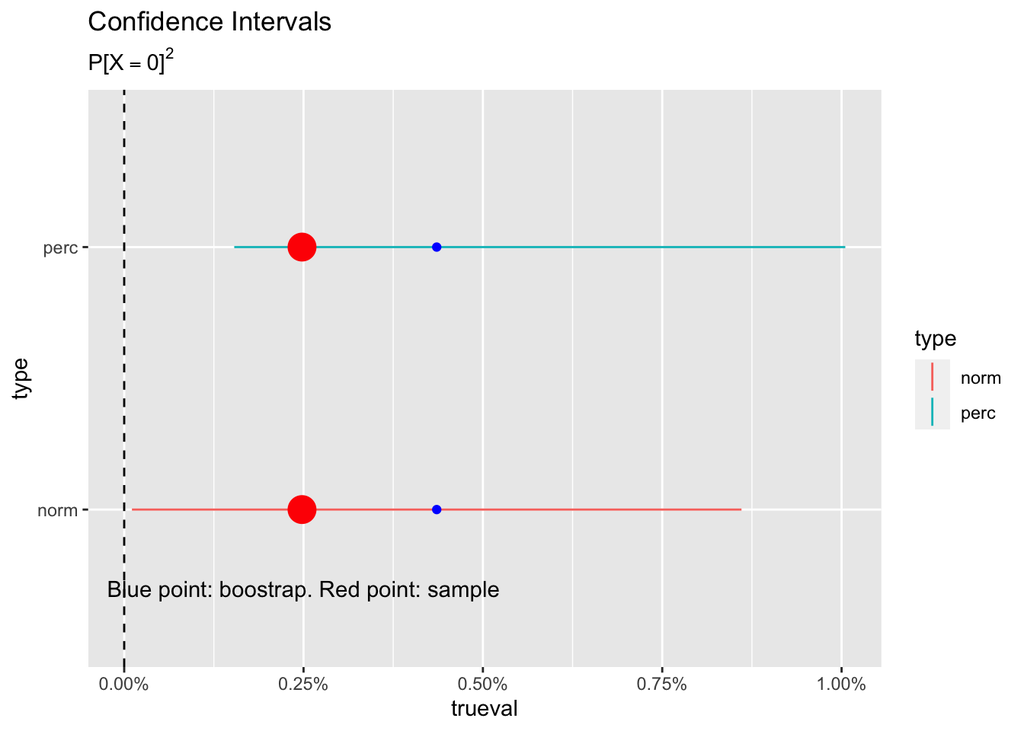

```r
# true value
trueval <- ppois(q = 0, lambda = 3)**2

# plot
tibble(
  x = replicate(2, mean(plug_boot)),
  low = c(cinorm[1], ciperc[1]),
  up = c(cinorm[2], ciperc[2]),
  type = c("norm", "perc")
) |>
  ggplot(aes(type, ymin = low, ymax = up, color = type)) +
  geom_linerange() +
  geom_point(aes(y = trueval), color = "red", size = 6) +
  geom_point(aes(y = mean(plug_boot)), color = "blue") +
  geom_hline(yintercept = 0, linetype = 2) +
  ggtitle("Confidence Intervals", TeX("$ P[X = 0]^{2}$")) +
  scale_y_continuous(labels = scales::percent) +
  annotate("text", x = 0.7, y = 0.0025, label = "Blue point: boostrap. Red point: sample") +
  coord_flip()
```

1. Repite el proceso descrito 500 veces y llena la siguiente tabla:

| Método | % fallo izquierda | % fallo derecha | cobertura |
| --- | --- | --- | --- |
| Normal |  |  | . |
| Percentiles |  |  |  |

La columna cobertura es una estimación de la cobertura del intervalo basada en las simulaciones, para calcularla simplemente escribe el porcentaje de los intervalos que incluyeron el verdadero valor del parámetro. Recuerda usar la semilla.

```r
get_coverage <- function(x, realx, n, B){
  # plugin as function
  plug_boot_fun <- function(i, x, B) {
    # sample
    boot_sample <- sapply(1:B, function(z) plugin_poiss(sample(x, size = length(x), replace = TRUE)))

    # ci
    alpha <- 0.05
    mean_boot <- mean(boot_sample)
    std_boot <- sd(boot_sample)
    cinorm <- c(mean_boot + qnorm(alpha/2)*std_boot, mean_boot + qnorm(1-alpha/2)*std_boot)
    ciperc <- quantile(boot_sample, p = c(alpha/2, 1-alpha/2))

    # return tibble
    df_return <- tibble(
      estimate = mean_boot,
      ci = c(cinorm, ciperc),
      part_ci = rep(c("lower", "upper"), times = 2),
      type_ci = rep(c("normal", "percentile"), times = 2*c(1, 1)),
      num_sample = i
    )
    return(df_return)
  }

  # generate n confidence intervals
  tibble_ci <- map_df(1:n, plug_boot_fun, x = x, B = B) |>
    group_by(num_sample, type_ci) |>
    mutate(
      failure = factor(ifelse((realx < ci[part_ci == "lower"]) | (realx > ci[part_ci == "upper"]), "yes", "no"))
    )

  # get failures
  tibble_smry <- tibble_ci |>
    group_by(num_sample, type_ci) |>
    summarise(
      failure_left = ifelse(realx < ci[part_ci == "lower"], 1, 0),
      failure_right = ifelse(realx > ci[part_ci == "upper"], 1, 0),
      long = diff(range(ci)),
      lower = ci[part_ci == "lower"],
      upper = ci[part_ci == "upper"]
    ) |>
    group_by(type_ci) |>
    summarise(
      num_sims = n,
      num_failure_left = sum(failure_left),
      num_failure_right = sum(failure_right),
      mean_long = mean(long),
      min_up = min(upper),
      max_low = max(lower)
    )  |>
    ungroup() |>
    mutate(
      coverage = (n - (num_failure_left + num_failure_right)),
      perc_coverage = 100 * (coverage / n)
      )

  return(list(df_boot = tibble_ci, df_coverage = tibble_smry))

}
# get coverage
list_cover <- get_coverage(x = xpoiss, realx = trueval, n = 500, B = B)
knitr::kable(list_cover$df_coverage)
```

| type_ci | num_sims | num_failure_left | num_failure_right | mean_long | min_up | max_low | coverage | perc_coverage |
| --- | --- | --- | --- | --- | --- | --- | --- | --- |
| normal | 500 | 0 | 0 | 0.0080545 | 0.0078622 | 0.0006036 | 500 | 100 |
| percentile | 500 | 0 | 0 | 0.0078326 | 0.0085656 | 0.0017277 | 500 | 100 |

2. Realiza una gráfica de páneles, en cada panel mostrarás los resultados de uno de los métodos (normal, percentiles), el eje x corresponderá al número de intervalo de confianza ($1,...,500$) y en ele eje vertical grafica el intervalo, usando color para indicar si cubrió al verdadero valor $exp(-2\lambda)$.

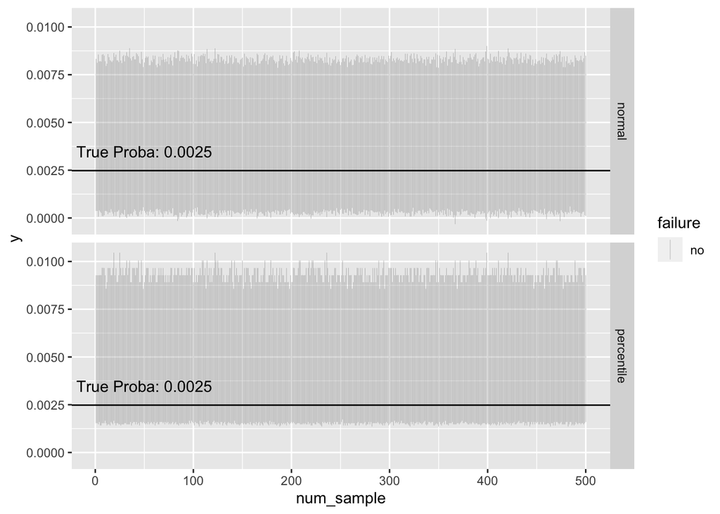

```r
# plot coverage
list_cover$df_boot |>
  pivot_wider(names_from = part_ci, values_from = ci) |>
  ggplot(aes(num_sample, ymin = lower, ymax = upper, color = failure)) +
  geom_linerange(size = 0.1) +
  geom_hline(yintercept = trueval, linetype = 1) +
  annotate("text", x =  50, y = trueval + 0.001, label = str_glue("True Proba: {round(trueval, 4)}")) +
  facet_grid(type_ci ~ .) +
  scale_color_manual(values = c("no" = "gray60", "yes" = "darkred"))
```

3. Repite considerando que se selecciona una muestra de tamaño n = 100. (duda: sobre de quién?)

```r
# get coverage
list_cover <- get_coverage(x = xpoiss, realx = trueval, n = 500, B = 100)
knitr::kable(list_cover$df_coverage)
```

| type_ci | num_sims | num_failure_left | num_failure_right | mean_long | min_up | max_low | coverage | perc_coverage |
| --- | --- | --- | --- | --- | --- | --- | --- | --- |
| normal | 500 | 0 | 0 | 0.0079809 | 0.0069347 | 0.0012691 | 500 | 100 |
| percentile | 500 | 0 | 0 | 0.0075252 | 0.0070129 | 0.0021532 | 500 | 100 |

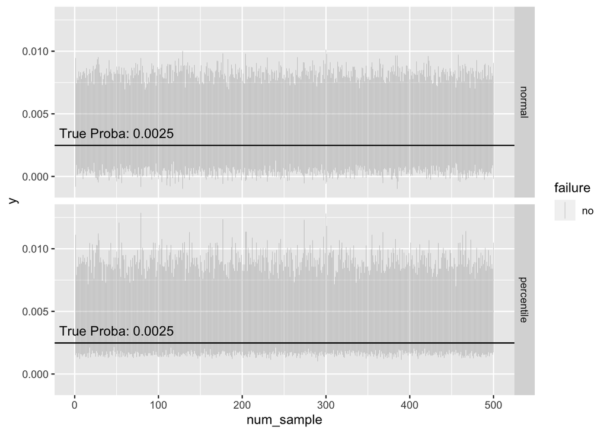

```r
list_cover$df_boot |>
  pivot_wider(names_from = part_ci, values_from = ci) |>
  ggplot(aes(num_sample, ymin = lower, ymax = upper, color = failure)) +
  geom_linerange(size = 0.1) +
  geom_hline(yintercept = trueval, linetype = 1) +
  annotate("text", x =  50, y = trueval + 0.001, label = str_glue("True Proba: {round(trueval, 4)}")) +
  facet_grid(type_ci ~ .) +
  scale_color_manual(values = c("no" = "gray60", "yes" = "darkred"))
```